# LWB WIOA Strategic Plans

Amy Shuff

2024-02-20

# Methodology

Each one of the 28 Texas Local Workforce Boards’ (LWBs) Strategic Plans were downloaded.

https://www.twc.texas.gov/agency/workforce-development-boards

Questions I have:

- Should it be called a Workforce Innovation & Opportunity Act (WIOA) plan instead?
- Currently, I need to verify that I have the 2-year modification plans for East Texas, Southeast Texas, South Texas, and Texoma. From looking at their files, I could not see that what I have is updated and not the 2021 version.

The TidyText R package is being utilized for most of this analysis: https://www.tidytextmining.com/tidytext

# Word Count

Stop words (common words such as “it”, “the”, “to”, etc.) were removed. Numbers and punctuation were taken out as well.

I then performed a word count. Here we can see the number of words used in each strategic plan. The statewide TWC has the most and Brazos Valley has less than all other regions.

Total Words in each Region

| Region | Total Words |
| --- | --- |
| TWC | 94551 |
| Alamo | 36572 |
| Cameron | 29162 |
| West Central Texas | 28685 |
| Panhandle | 21623 |
| Gulf Coast | 19662 |
| Texoma | 19183 |
| Tarrant County | 18469 |
| Central Texas | 17738 |
| Borderplex | 17351 |
| Lower Rio Grande Valley | 16893 |
| Northeast Texas | 15530 |
| Southeast Texas | 15522 |
| Rural Capital Area | 15329 |
| Permian-Basin | 14991 |
| Golden Crescent | 14984 |
| Greater Dallas | 14374 |
| North Texas | 14247 |
| Deep East Texas | 14007 |
| North Central Texas | 13797 |
| South Plains | 13607 |
| Coastal Bend | 12855 |
| South Texas | 12726 |
| Heart of Texas | 12211 |
| East Texas | 11478 |
| Concho Valley | 11005 |
| Capital Area | 10484 |
| Middle Rio Grande | 10406 |
| Brazos Valley | 6703 |

25 Most Frequently Used Words

| word | n | rank |
| --- | --- | --- |
| workforce | 9474 | 1 |
| services | 8492 | 2 |
| training | 6756 | 3 |
| board | 5985 | 4 |
| texas | 4885 | 5 |
| employment | 4479 | 6 |
| programs | 4034 | 7 |
| education | 3952 | 8 |
| job | 3763 | 9 |
| program | 3600 | 10 |
| development | 3585 | 11 |
| local | 3403 | 12 |
| employers | 3164 | 13 |
| system | 3123 | 14 |
| career | 3097 | 15 |
| plan | 2997 | 16 |
| service | 2904 | 17 |
| staff | 2754 | 18 |
| wioa | 2734 | 19 |
| skills | 2696 | 20 |
| information | 2598 | 21 |
| work | 2480 | 22 |
| youth | 2454 | 23 |
| support | 2388 | 24 |
| individuals | 2163 | 25 |

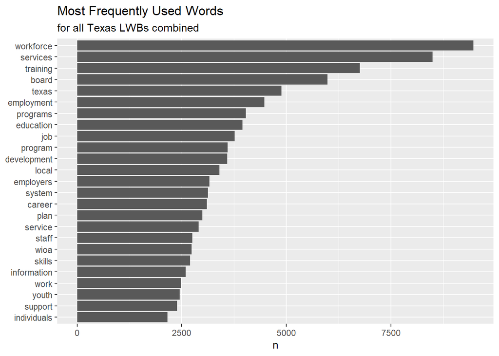

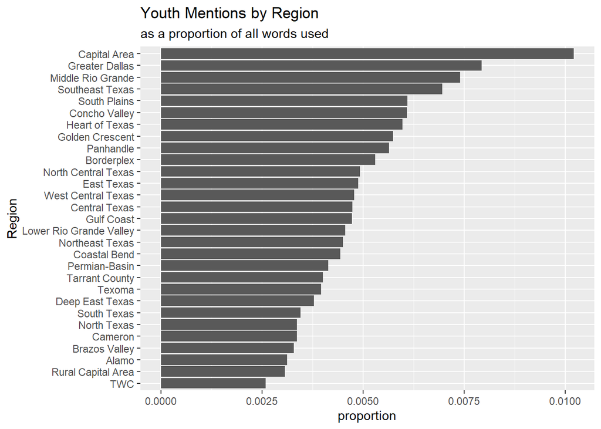

# Sentiment Analysis

Name: AFINN-111 URL: http://www2.imm.dtu.dk/pubdb/views/publication_details.php?id=6010 License: Open Database License (ODbL) v1.0

Citation info:

This dataset was published in Saif M. Mohammad and Peter Turney. (2013), ``Crowdsourcing a Word-Emotion Association Lexicon.’’ Computational Intelligence, 29(3): 436-465.

article{mohammad13, author = {Mohammad, Saif M. and Turney, Peter D.}, title = {Crowdsourcing a Word-Emotion Association Lexicon}, journal = {Computational Intelligence}, volume = {29}, number = {3}, pages = {436-465}, doi = {10.1111/j.1467-8640.2012.00460.x}, url = {https://onlinelibrary.wiley.com/doi/abs/10.1111/j.1467-8640.2012.00460.x}, eprint = {https://onlinelibrary.wiley.com/doi/pdf/10.1111/j.1467-8640.2012.00460.x}, year = {2013} } If you use this lexicon, then please cite it.

10 Most Frequently Used Sentiment Words

| sentiment | word | n |
| --- | --- | --- |
| positive | work | 2480 |
| positive | support | 2388 |
| positive | improve | 669 |
| negative | dislocated | 652 |
| positive | skill | 584 |
| positive | integrated | 490 |
| positive | enhance | 440 |
| positive | rapid | 408 |
| negative | critical | 394 |
| positive | skilled | 394 |

Because “work” is seen as positive in this sentiment dataset, I removed it. In these texts I think it’s mostly a neutral term.

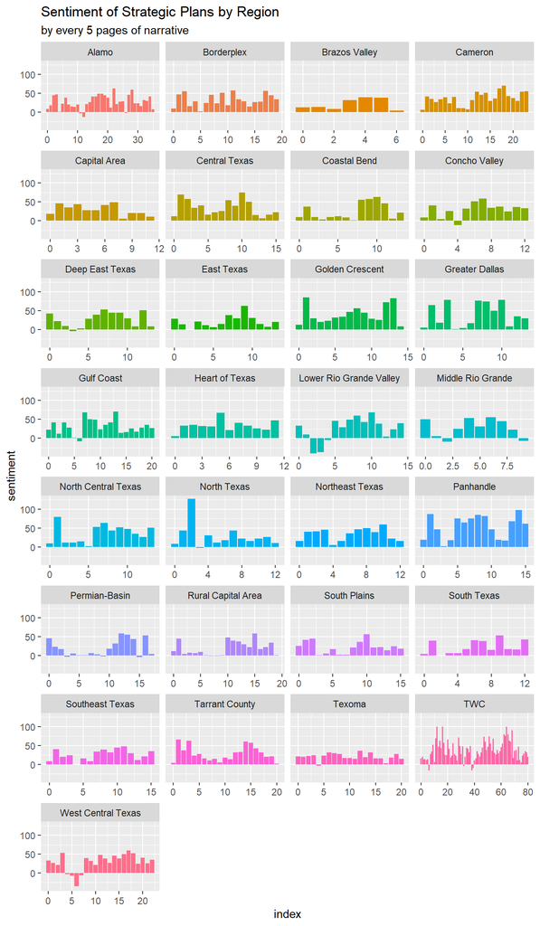

# Term Frequency - Inverse Document Frequency (tf-idf)

“The idea of tf-idf is to find the important words for the content of each document by decreasing the weight for commonly used words and increasing the weight for words that are not used very much in a collection or corpus of documents.”

None of these words occur in all of the texts. They are important, characteristic words for each region.

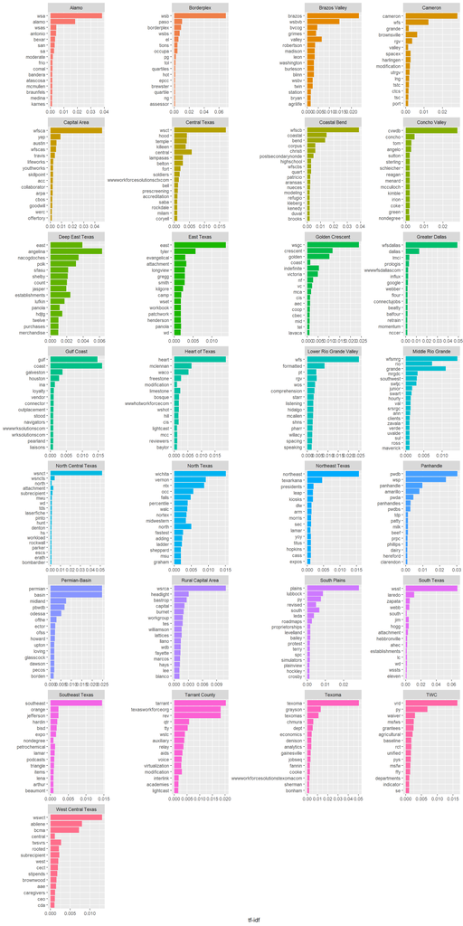

In Heart of Texas and Golden Crescent, CIS is Communities in Schools.

# N-Grams

## Bigrams

Examining pairs of two consecutive words, often called “bigrams”

10 most common words preceding youth for all LWBs

| word1 | n |
| --- | --- |
| foster | 263 |
| school | 128 |
| wioa | 101 |
| opportunity | 69 |
| exit | 63 |
| disconnected | 35 |
| eligible | 24 |
| including | 22 |
| rate | 22 |
| risk | 14 |

I think “school youth” comes from the phrases: “in school youth” and “out of school youth”.

TF-IDF for Bigrams

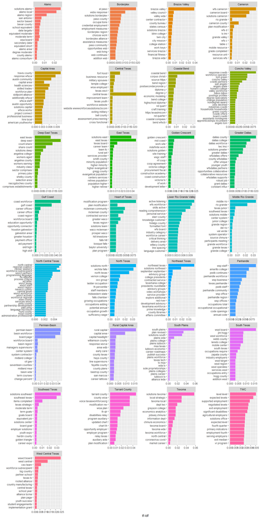

Opportunity Youth made Capital Area’s top 15. East Texas evangelical language is interesting. West Central Texas mentions youth success.

## Trigrams

This looks at groups of three words instead of pairs. I’m specifically interested in “out of school.”

I’m going to try it with stop words included because “out of school” is tricky otherwise (both “out” and “of” are stop words.)

Out of School Mentions

| trigram | Region | n |
| --- | --- | --- |
| out of school | TWC | 21 |
| out of school | Southeast Texas | 10 |
| out of school | Borderplex | 8 |
| out of school | Panhandle | 7 |
| out of school | Cameron | 6 |
| out of school | Golden Crescent | 6 |
| out of school | Heart of Texas | 6 |
| out of school | Middle Rio Grande | 6 |
| out of school | Brazos Valley | 4 |
| out of school | Coastal Bend | 4 |
| out of school | Permian-Basin | 4 |
| out of school | Gulf Coast | 3 |
| out of school | Northeast Texas | 3 |
| out of school | Alamo | 2 |
| out of school | Capital Area | 2 |
| out of school | Central Texas | 2 |
| out of school | Concho Valley | 2 |
| out of school | East Texas | 2 |
| out of school | Greater Dallas | 2 |
| out of school | Lower Rio Grande Valley | 2 |
| out of school | Rural Capital Area | 2 |
| out of school | South Plains | 2 |
| out of school | South Texas | 2 |
| out of school | Texoma | 2 |
| out of school | West Central Texas | 2 |
| out of school | Deep East Texas | 1 |
| out of school | North Central Texas | 1 |
| out of school | North Texas | 1 |
| out of school | Tarrant County | 1 |

Every region mentioned “out of school” at least once.

Youth Mentions with Stop Words Included

| trigram | n |
| --- | --- |
| youth with disabilities | 111 |
| worker and youth | 109 |
| of school youth | 93 |
| workers and youth | 92 |
| foster youth and | 73 |
| post exit youth | 61 |
| and youth services | 51 |
| activities for youth | 49 |
| youth activities and | 47 |
| former foster youth | 43 |
| youth and individuals | 43 |
| and youth programs | 42 |
| for youth and | 42 |
| for youth with | 42 |
| c youth activities | 39 |

Youth Mentions without Stop Words

| trigram | n | rank |
| --- | --- | --- |
| post exit youth | 61 | 132 |
| youth employed enrolled | 31 | 290 |
| wioa youth program | 27 | 342 |
| credential rate youth | 22 | 434 |
| youth credential rate | 19 | 577 |
| disabilities foster youth | 17 | 649 |
| exit youth employed | 16 | 718 |
| exit youth credential | 13 | 891 |
| eligible foster youth | 11 | 1092 |
| including opportunity youth | 11 | 1103 |
| opportunity youth collaborative | 10 | 1243 |
| younger youth customers | 10 | 1297 |
| youth career expo | 10 | 1298 |
| youth measurable skills | 10 | 1299 |
| youth program elements | 10 | 1300 |

I think “post exit youth” and also “former foster youth” are interesting. Is disability a risk factor for OY?

## Quadgrams

Alamo used the phrase “on the job training” a total of 107 times in their strategic plan.

Northeast Texas uses OS for out of school.

TWC uses the word “youths”.

Here I’m making sure that out of school pertains to youth and not after school programs

Phrases begining with ‘out of school’

| quadgram | n |
| --- | --- |
| out of school youth | 92 |
| out of school or | 3 |
| out of school the | 3 |
| out of school and | 2 |
| out of school individuals | 2 |
| out of school 6 | 1 |
| out of school boards | 1 |
| out of school expenditure | 1 |
| out of school goal | 1 |
| out of school literacy | 1 |
| out of school msfw | 1 |
| out of school os | 1 |
| out of school osy | 1 |
| out of school referrals | 1 |
| out of school seal | 1 |
| out of school services | 1 |
| out of school through | 1 |
| out of school would | 1 |
| out of school youths | 1 |
| out of schoolout of | 1 |

# Final Phrase Counts

These phrase counts will be done with clean data and will be more accurate than the initial ones I did.

- Opportunity Youth also includes OY.
- Disconnected Youth also includes DY.

– There are no mentions of “youth that are disconnected”, “disconnected teenagers”, “disconnected young people”, or “youth disconnection”

- Out of School includes out of school youth, out of school youths, OSY, OS, dropout, drop out, dropouts, and drop out of school.

– “nor in school” had zero mentions

Alamo used the phrase “bachelor’s degree none” at least 88 times, which may be related to opportunity youth.

Any Related Opportunity Youth Mentions

| Region | Opportunity Youth | Disconnected Youth | Out of School | Total Mentions | Rank |
| --- | --- | --- | --- | --- | --- |
| TWC | 1 | 0 | 36 | 37 | 1 |
| Greater Dallas | 26 | 2 | 5 | 33 | 2 |
| Capital Area | 20 | 0 | 5 | 25 | 3 |
| Borderplex | 5 | 2 | 11 | 18 | 4 |
| Panhandle | 3 | 6 | 9 | 18 | 5 |
| Golden Crescent | 2 | 1 | 14 | 17 | 6 |
| Cameron | 2 | 0 | 13 | 15 | 7 |
| Middle Rio Grande | 0 | 2 | 11 | 13 | 8 |
| Alamo | 1 | 2 | 8 | 11 | 9 |
| Southeast Texas | 1 | 0 | 10 | 11 | 10 |
| Gulf Coast | 7 | 0 | 3 | 10 | 11 |
| West Central Texas | 0 | 2 | 8 | 10 | 12 |
| Heart of Texas | 0 | 0 | 8 | 8 | 13 |
| Permian-Basin | 0 | 0 | 7 | 7 | 14 |
| Coastal Bend | 0 | 0 | 6 | 6 | 15 |
| East Texas | 0 | 1 | 5 | 6 | 16 |
| Rural Capital Area | 0 | 2 | 4 | 6 | 17 |
| South Plains | 0 | 1 | 5 | 6 | 18 |
| Brazos Valley | 0 | 0 | 5 | 5 | 19 |
| Lower Rio Grande Valley | 0 | 0 | 5 | 5 | 20 |
| Texoma | 0 | 2 | 3 | 5 | 21 |
| Concho Valley | 1 | 0 | 3 | 4 | 22 |
| Northeast Texas | 0 | 1 | 3 | 4 | 23 |
| South Texas | 0 | 0 | 4 | 4 | 24 |
| Central Texas | 0 | 0 | 3 | 3 | 25 |
| Deep East Texas | 1 | 0 | 2 | 3 | 26 |
| Tarrant County | 1 | 1 | 1 | 3 | 27 |
| North Central Texas | 0 | 1 | 1 | 2 | 28 |
| North Texas | 0 | 0 | 1 | 1 | 29 |

Next I wanted to create a table for mentions of risk factors, like homelessness.

Words following homeless (with more than two mentions)

| bigram | homeless |
| --- | --- |
| homeless individuals | 18 |
| homeless and | 7 |
| homeless or | 5 |
| homeless shelters | 4 |
| homeless children | 3 |
| homeless youth | 3 |

Only three regions directly mention homeless youth. One example is the Panhandle:

“In addition to continuing to serve low-income youth, , youth who have disabilities, foster youth, and youth who have barriers to employment, refocusing efforts to outreach and *engage out of school youth in successful work-based training opportunities is the primary goal of the PWDB*, related to youth services.”

The homeless counts below are for any mention of homeless, not just youth related. Even so, only 21 regions have mentions.

- Homeless includes homeless and homelessness.
- “Unhoused” is not used at all in any text.

Homeless Mentions

| Region | Homeless | Rank |
| --- | --- | --- |
| TWC | 25 | 1 |
| Gulf Coast | 13 | 2 |
| Alamo | 6 | 3 |
| Texoma | 6 | 4 |
| East Texas | 5 | 5 |
| Golden Crescent | 4 | 6 |
| Northeast Texas | 4 | 7 |
| Cameron | 3 | 8 |
| Capital Area | 3 | 9 |
| Middle Rio Grande | 3 | 10 |
| West Central Texas | 3 | 11 |
| Borderplex | 2 | 12 |
| Brazos Valley | 2 | 13 |
| Concho Valley | 2 | 14 |
| Heart of Texas | 2 | 15 |
| Panhandle | 2 | 16 |
| Permian-Basin | 2 | 17 |
| Deep East Texas | 1 | 18 |
| Rural Capital Area | 1 | 19 |
| South Plains | 1 | 20 |
| Tarrant County | 1 | 21 |
| Central Texas | 0 | 22 |
| Coastal Bend | 0 | 23 |
| Greater Dallas | 0 | 24 |
| Lower Rio Grande Valley | 0 | 25 |
| North Central Texas | 0 | 26 |
| North Texas | 0 | 27 |
| South Texas | 0 | 28 |
| Southeast Texas | 0 | 29 |

# Youth Sentiment

Note: “Disconnected” wasn’t in the sentiment dataset I used, so I manually added it.

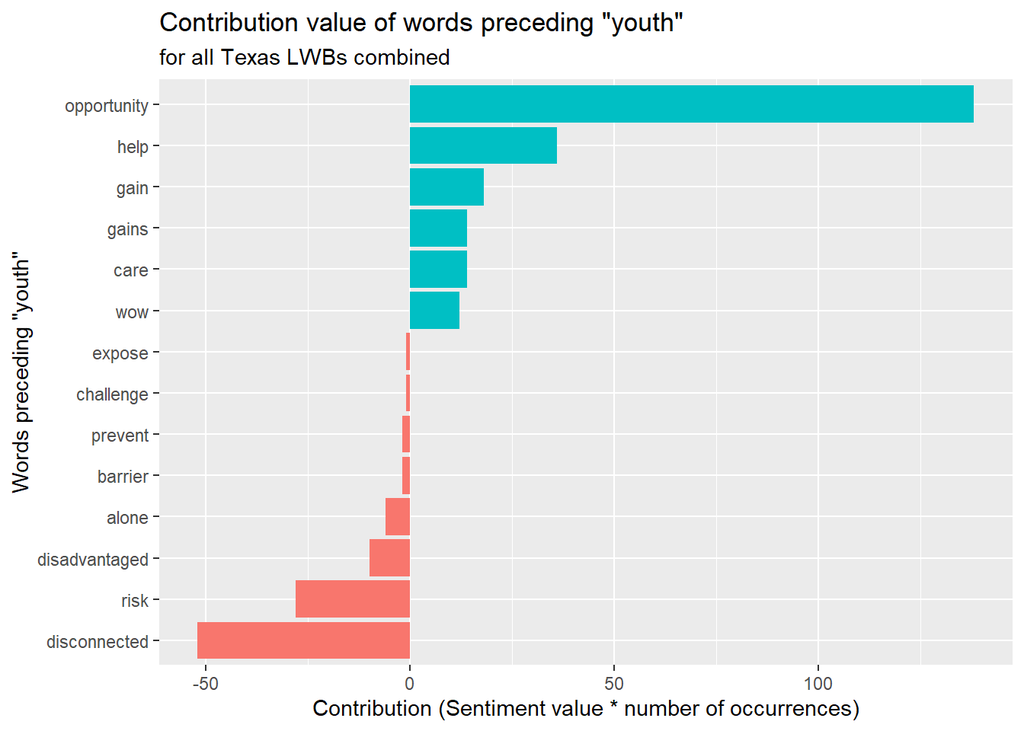

# Word Associations

This section follows this tutorial : https://www.red-gate.com/simple-talk/databases/sql-server/bi-sql-server/text-mining-and-sentiment-analysis-with-r/

Top 25 Words Associcated with Youth

| youth | correlation |
| --- | --- |
| grant | 0.90 |
| focused | 0.89 |
| training | 0.88 |
| employers | 0.88 |
| based | 0.88 |
| opportunities | 0.88 |
| current | 0.88 |
| eligibility | 0.88 |
| implementation | 0.88 |
| determined | 0.88 |
| conditions | 0.88 |
| education | 0.87 |
| community | 0.87 |
| pursue | 0.87 |
| identify | 0.86 |
| develop | 0.86 |
| success | 0.86 |
| approach | 0.86 |
| collection | 0.86 |
| services | 0.85 |
| plan | 0.85 |
| support | 0.85 |
| providers | 0.85 |
| address | 0.85 |
| standards | 0.85 |

Top 25 Words Associcated with Young

| young | correlation |
| --- | --- |
| outplacement | 0.91 |
| reskill | 0.91 |
| xi | 0.91 |
| xii | 0.91 |
| upskill | 0.85 |
| centrally | 0.84 |
| vendors | 0.83 |
| connector | 0.83 |
| good | 0.83 |
| dozen | 0.83 |
| hunger | 0.83 |
| railroad | 0.83 |
| gulf | 0.82 |
| coast | 0.82 |
| galveston | 0.82 |
| ina | 0.82 |
| pearland | 0.82 |
| wrksolutionscom | 0.82 |
| wwwwrksolutionscom | 0.82 |
| acam | 0.82 |
| diversion | 0.82 |
| docket | 0.82 |
| hshg | 0.82 |
| nextgen | 0.82 |
| poc | 0.82 |

# Topic Modeling

“Latent Dirichlet allocation (LDA) is a particularly popular method for fitting a topic model. It treats each document as a mixture of topics, and each topic as a mixture of words.”

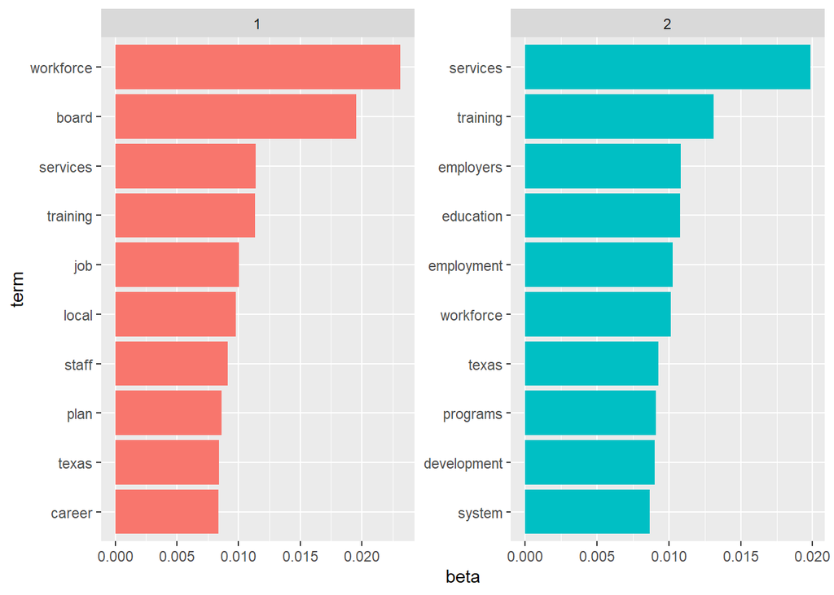

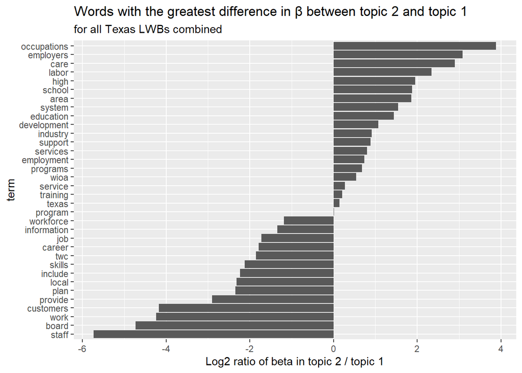

Idea: View the Board Oversight Capacity score card for your Board. Every year, the Texas Workforce Commission (TWC) assesses how well each Board uses local funds and provides local workforce services.